# 第3回（10/11） データ分析課題

更新：2022-09-07 16:43:52

## 課題①

### データ読み込み＆対数変換

```r
# パッケージの読み込み
library(forecast)
library(tseries)
library(ggplot2)
library(ggfortify)

# データの読み込み
## 47都道府県データ読み込み
all_pref <- read.csv("data/monthly_hotel_data.csv", skip = 1)  # 1行目の都道府県名は除外
all_pref <- all_pref[, 3:49]  # year，month列（1,2列目）の除外

## ts型への変更
all_pref <- ts(all_pref, start = c(2011, 1), frequency = 12)

## 沖縄データの抽出 & 表示
okinawa <- all_pref[, "y47"]

## 対数変換
okinawa_log <- log(okinawa)
```

### 原系列と対数変換系列のグラフ比較

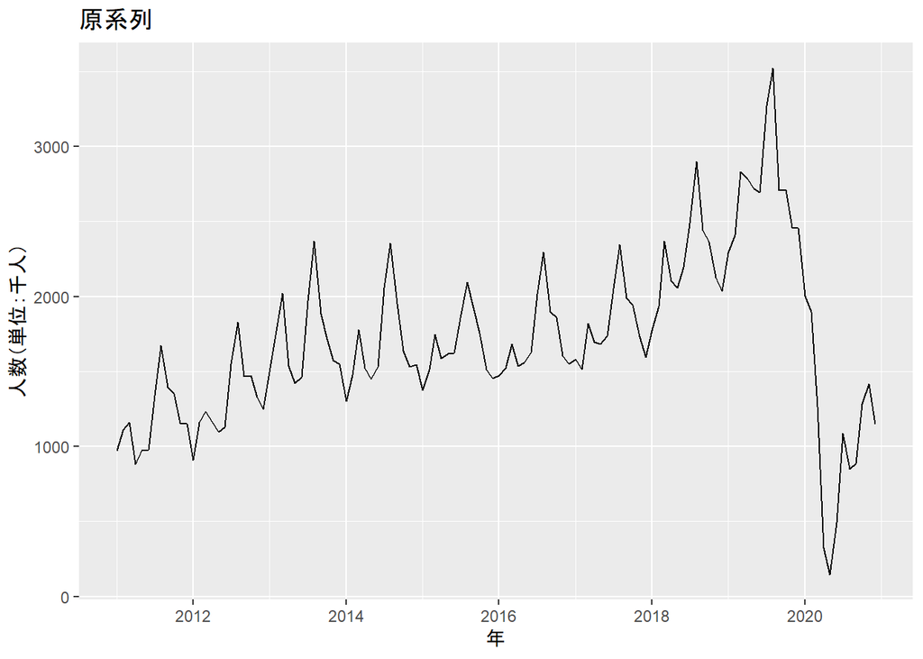

```r
# 原系列
autoplot(okinawa/1000,
         main = "原系列",
         xlab = "年",
         ylab = "人数（単位：千人）")
```

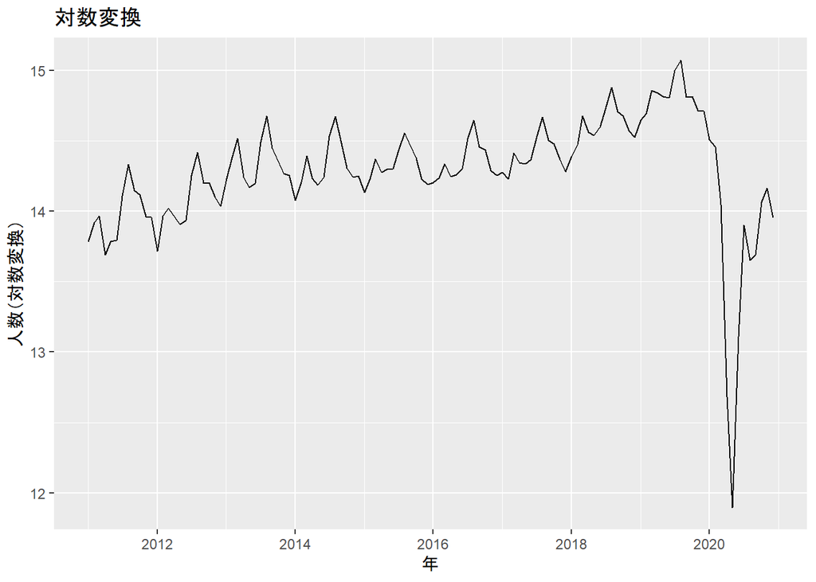

```r
# 対数変換
autoplot(okinawa_log,
         main = "対数変換",
         xlab = "年",
         ylab = "人数（対数変換）")
```

### パラメータ推定（教科書7-10）

- 教科書のコード通り `auto.arima` 関数の引数に `parallel = T, num.cores = 4` を追加して，`Error in mclapply...` とエラーが表示される場合は，この2つの引数を削除して実行する。
- 以下の例では2011年1月～2018年12月（96ヶ月間）をパラメータ推定用の訓練データ期間，2019年1月～2020年12月（24ヶ月間）を予測力検証用のテストデータ期間とした。

```r
# 訓練データとテストデータへの分割
train <- window(okinawa_log, end = c(2018, 12))
test <- window(okinawa_log, start = c(2019, 1))

# ARIMAモデルの推定(auto.arima)
arima_okinawa <- auto.arima(
  y = train,
  ic = "aic",
  max.order = 7,
  stepwise = F,
  approximation = F
  )

# 推計結果
arima_okinawa
```

```
## Series: train
## ARIMA(1,0,0)(0,1,1)[12] with drift
##
## Coefficients:
##          ar1     sma1   drift
##       0.7885  -0.6401  0.0067
## s.e.  0.0666   0.1141  0.0014
##
## sigma^2 = 0.005367:  log likelihood = 98.51
## AIC=-189.03   AICc=-188.52   BIC=-179.3
```

## 課題②

### 予測と評価（教科書7-13）

```r
# 予測
arima_f <- forecast(
  arima_okinawa,
  h = 24,
  level = c(95, 70)
  )

# 予測結果
arima_f
```

```
##          Point Forecast    Lo 70    Hi 70    Lo 95    Hi 95
## Jan 2019       14.52956 14.45360 14.60552 14.38592 14.67320
## Feb 2019       14.57513 14.47842 14.67185 14.39223 14.75803
## Mar 2019       14.72916 14.62154 14.83679 14.52564 14.93269
## Apr 2019       14.60750 14.49363 14.72138 14.39215 14.82285
## May 2019       14.58858 14.47099 14.70618 14.36620 14.81097
## Jun 2019       14.62646 14.50661 14.74631 14.39981 14.85311
## Jul 2019       14.79978 14.67854 14.92101 14.57051 15.02904
## Aug 2019       14.94048 14.81839 15.06256 14.70961 15.17135
## Sep 2019       14.76825 14.64564 14.89086 14.53639 15.00011
## Oct 2019       14.72145 14.59852 14.84438 14.48898 14.95393
## Nov 2019       14.60243 14.47930 14.72557 14.36958 14.83529
## Dec 2019       14.55529 14.43203 14.67854 14.32221 14.78837
## Jan 2020       14.56944 14.44217 14.69671 14.32877 14.81012
## Feb 2020       14.62356 14.49385 14.75326 14.37827 14.86884
## Mar 2020       14.78432 14.65312 14.91552 14.53622 15.03242
## Apr 2020       14.66797 14.53586 14.80009 14.41813 14.91781
## May 2020       14.65324 14.52055 14.78592 14.40232 14.90415
## Jun 2020       14.69442 14.56138 14.82745 14.44284 14.94600
## Jul 2020       14.87033 14.73708 15.00359 14.61834 15.12233
## Aug 2020       15.01309 14.87970 15.14648 14.76084 15.26534
## Sep 2020       14.84248 14.70901 14.97595 14.59007 15.09488
## Oct 2020       14.79696 14.66343 14.93048 14.54446 15.04946
## Nov 2020       14.67895 14.54539 14.81250 14.42639 14.93150
## Dec 2020       14.63259 14.49902 14.76616 14.38000 14.88518
```

### 予測結果の図示

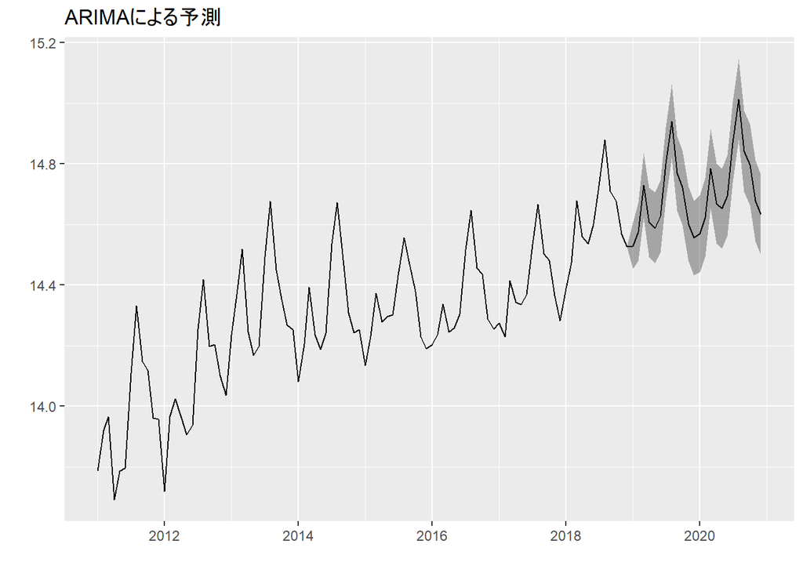

```r
autoplot(arima_f, predict.colour = 1, main = "ARIMAによる予測")
```

**（注意）**  
上記グラフの予測期間（2019年以降）の実線はテストデータ期間の予測値であり，実績値（＝実際に観測された値）ではない。 以下は，実績値，訓練データ期間の当てはめ値，テストデータ期間の予測値を同じグラフに描くRコード例（参考：教科書p.249）。

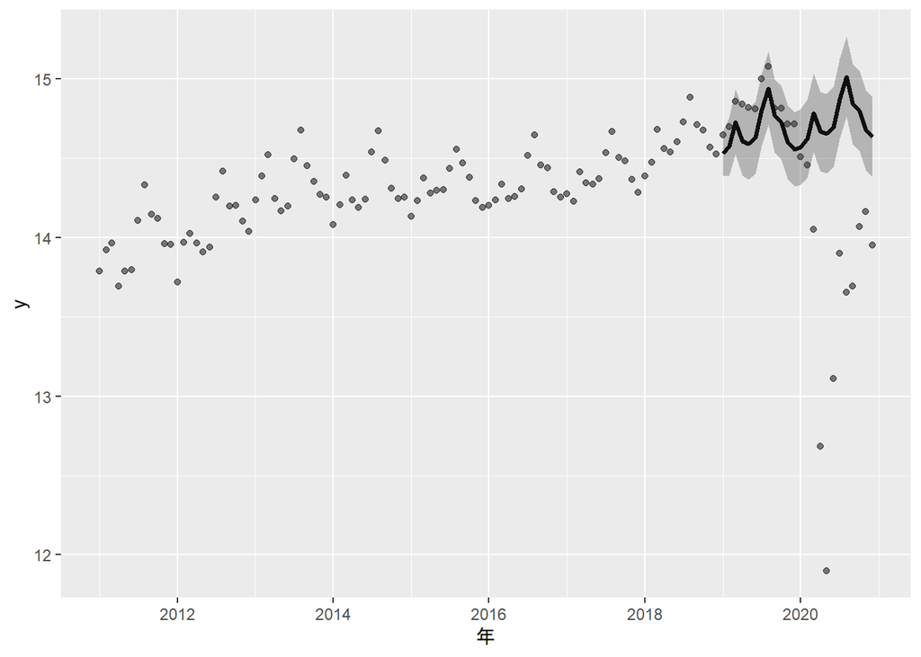

```r
df_forecast <- cbind(
  y = okinawa_log,
  fit = arima_f$mean,
  lower = arima_f$lower[, "95%"],
  upper = arima_f$upper[, "95%"]
)

ggplot(data = df_forecast, aes(x = seq(as.Date("2011/01/01"), as.Date("2020/12/01"), "months"), y = y)) +
  geom_point(alpha = 0.5) +
  geom_line(aes(y = fit), size = 1.2) +
  geom_ribbon(aes(ymin = lower, ymax = upper), alpha = 0.3) +
  xlab(label = "年")
```

⇒ 点が実績値，実線が予測値，灰色の区間が95％区間

### 予測精度の評価

```r
# 推定したARIMAモデルの予測精度
accuracy(arima_f, x = test)
```

```
##                        ME       RMSE        MAE        MPE     MAPE      MASE
## Training set  0.003748677 0.06729052 0.04671656  0.0261007 0.326962 0.3959073
## Test set     -0.456098444 0.91914234 0.60160818 -3.5399658 4.521434 5.0984292
##                     ACF1 Theil's U
## Training set -0.08581416        NA
## Test set      0.83176161  1.967869
```

```r
# ナイーブ予測（過去の平均値）
naive_f_mean <- meanf(train, h = 24)
accuracy(naive_f_mean, x = test)
```

```
##                         ME      RMSE       MAE         MPE     MAPE     MASE
## Training set -1.849453e-16 0.2388575 0.1852605 -0.02806669 1.298645 1.570021
## Test set     -5.047389e-02 0.7752843 0.5998115 -0.67835078 4.384760 5.083203
##                   ACF1 Theil's U
## Training set 0.8034859        NA
## Test set     0.8105685  1.627842
```

```r
# ナイーブ予測（直近の値）
naive_f_latest <- rwf(train, h = 24)
accuracy(naive_f_latest, x = test)
```

```
##                        ME      RMSE       MAE         MPE      MAPE      MASE
## Training set  0.007793605 0.1391182 0.1139911  0.05032612 0.7962783 0.9660369
## Test set     -0.279359770 0.8225327 0.5689723 -2.29010756 4.2386606 4.8218507
##                    ACF1 Theil's U
## Training set 0.08882617        NA
## Test set     0.81056846  1.760686
```

- 宿泊者数は2020年からの新型コロナウイルス感染拡大によって大きな影響を受けたため，RMSEではARIMAモデルの予測精度がナイーブ予測より悪い結果となった。
- 以下の通り，予測精度の検証期間を2019年に限定するとARIMAモデルの予測精度はナイーブ予測を上回る。

### 予測精度の評価（2019年に限定）

```r
# 推定モデルの予測精度の評価（2019年に限定）
arima_f_2019 <- window(arima_f$mean, end = c(2019, 12))
naive_f_mean_2019 <- window(naive_f_mean$mean, end = c(2019, 12))
naive_f_latest_2019 <- window(naive_f_latest$mean, end = c(2019, 12))

test_2019 <- window(test, end = c(2019, 12))

# 推定したARIMAモデルの予測精度
accuracy(arima_f_2019, test_2019)
```

```
##                 ME     RMSE       MAE       MPE      MAPE      ACF1 Theil's U
## Test set 0.1455097 0.155191 0.1455097 0.9814684 0.9814684 0.5385261  1.360355
```

```r
# ナイーブ予測（過去の平均値）
accuracy(naive_f_mean_2019, test_2019)
```

```
##                 ME      RMSE       MAE      MPE     MAPE      ACF1 Theil's U
## Test set 0.5184984 0.5317811 0.5184984 3.493522 3.493522 0.4306656  4.676657
```

```r
# ナイーブ予測（直近の値）
accuracy(naive_f_latest_2019, test_2019)
```

```
##                 ME      RMSE       MAE      MPE     MAPE      ACF1 Theil's U
## Test set 0.2896125 0.3127715 0.2896125 1.948553 1.948553 0.4306656   2.78091
```